# Análisis Matemático

## 12va Semana (03/03/2021). Funciones de activacion, dominio, derivadas para redes neuronales y regresion logística.

## Revision sobre derivadas parciales

Resolución de derivadas parciales de multiples variables con simpy

```python
from sympy import *
from sympy.plotting import plot
from sympy.abc import x
init_printing()
```

https://mzucker.github.io/2018/04/11/sympy-case-studies-part-2-derivatives.html

```python
x = Symbol('x', real=True)
y = Symbol('y', real=True)
g = exp(-(x**2 + y**2) / 2) * cos(pi*x)

for var in [x, y]:
    print(str(simplify(g.diff(var))))
```

```
-(x*cos(pi*x) + pi*sin(pi*x))*exp(-x**2/2 - y**2/2)
-y*exp(-x**2/2 - y**2/2)*cos(pi*x)
```

## La función de un modelo de regresión lineal es:

$$ y = \beta_0 + \beta_1 x_1 + \beta_2 x_2 $$

## Algoritmos de regresion logística

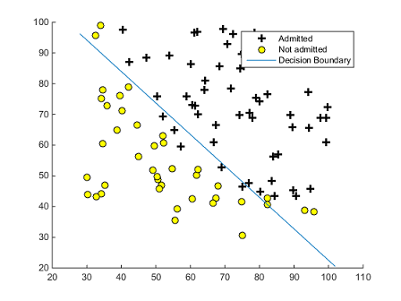

## en la regresión logístic la función es:

$$ y = \frac{1}{1 + e^{-f(x)}} ;\hspace{1cm} y = \frac{1}{1 + e^{-(\beta_0 + \beta_1 x_1 + \beta_2 x_2)}} $$

https://www.aprendemachinelearning.com/regresion-logistica-con-python-paso-a-paso/

## Redes neuronales

https://www.aprendemachinelearning.com/crear-una-red-neuronal-en-python-desde-cero/

https://github.com/shayanalibhatti/Coding-neural_network-for-XOR-logic-from-scratch.git

Forward y Backward propagation https://d2l.ai/chapter_multilayer-perceptrons/backprop.html

## Función sigmoid

En los inicios de las redes neuronales se utilizó la función de activación sigmoide debido a la propiedad que tiene de mapear el dominio de los reales al intervalo (0,1), con lo cual se asemeja a una distribución de probabilidad. La función sigmoide sufre de un problema conocido como covariate shift, debido a que la salida de la función se encuentra centrada en 0.5 existe un desplazamiento de la salida de las neuronas que ocasiona que los pesos tengan problemas de convergencia.

```python
x = Symbol('x', real=True)
f = 1/(1+exp(-x))
dfdx = f.diff(x) # <- yes, taking derivatives is this easy!
print("f'(x) = " +  str(simplify(dfdx)))
```

```
f'(x) = 1/(4*cosh(x/2)**2)
```

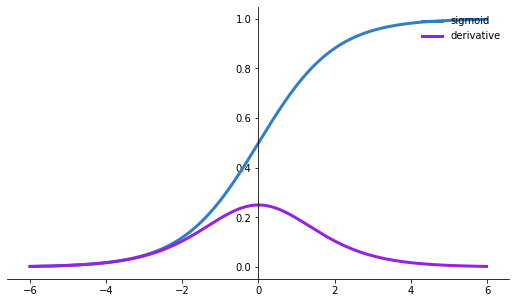

```python
import matplotlib.pyplot as plt
import numpy as np

def sigmoid(x):
    s=1/(1+np.exp(-x))
    ds=s*(1-s)
    return s,ds
x=np.arange(-6,6,0.01)
sigmoid(x)
# Setup centered axes
fig, ax = plt.subplots(figsize=(9, 5))
ax.spines['left'].set_position('center')
ax.spines['right'].set_color('none')
ax.spines['top'].set_color('none')
ax.xaxis.set_ticks_position('bottom')
ax.yaxis.set_ticks_position('left')
# Create and show plot
ax.plot(x,sigmoid(x)[0], color="#307EC7", linewidth=3, label="sigmoid")
ax.plot(x,sigmoid(x)[1], color="#9621E2", linewidth=3, label="derivative")
ax.legend(loc="upper right", frameon=False)
fig.show()
```

## Funcion tangente hyperbólica

## Tanh

Esta función mapea el dominio de los reales al intervalo abierto (-1, 1). Debido a lo anterior se encuentra centrada en 0 y elimina el problema del covariate shift. De igual forma su derivada es más “activa” que la sigmoide, lo cual perimite reducir tiempos de entrenamiento y convergencia, sin embargo, también sufre de saturación de gradiente a los extremos de la función:

```python
x = Symbol('x', real=True)
f = (exp(x) - (exp(-x)))/(exp(x) + (exp(-x)))
dfdx = f.diff(x) # <- yes, taking derivatives is this easy!
print("f'(x) = " +  str(simplify(dfdx)))
```

```
f'(x) = 4*exp(2*x)/(exp(4*x) + 2*exp(2*x) + 1)
```

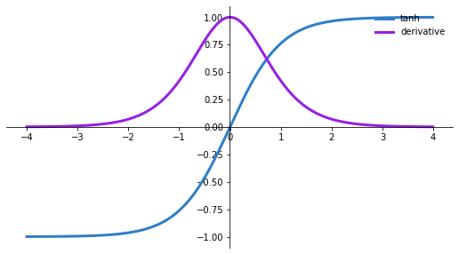

```python
import matplotlib.pyplot as plt
import numpy as np

def tanh(x):
    t=(np.exp(x)-np.exp(-x))/(np.exp(x)+np.exp(-x))
    dt=1-t**2
    return t,dt
z=np.arange(-4,4,0.01)
tanh(z)[0].size,tanh(z)[1].size
# Setup centered axes
fig, ax = plt.subplots(figsize=(9, 5))
ax.spines['left'].set_position('center')
ax.spines['bottom'].set_position('center')
ax.spines['right'].set_color('none')
ax.spines['top'].set_color('none')
ax.xaxis.set_ticks_position('bottom')
ax.yaxis.set_ticks_position('left')
# Create and show plot
ax.plot(z,tanh(z)[0], color="#307EC7", linewidth=3, label="tanh")
ax.plot(z,tanh(z)[1], color="#9621E2", linewidth=3, label="derivative")
ax.legend(loc="upper right", frameon=False)
fig.show()
```

https://github.com/ImadDabbura/blog-posts/blob/master/notebooks/Coding-Neural-Network-Forwad-Back-Propagation.ipynb

## Ejercicios

https://github.com/ImadDabbura/blog-posts.git

https://towardsdatascience.com/coding-neural-network-forward-propagation-and-backpropagtion-ccf8cf369f76

## Algoritmos y ejemplos en Python.

https://www.aprendemachinelearning.com/principales-algoritmos-usados-en-machine-learning/